# Signature Search Results

# Class A - Gio

Read in the exported data from the GPCRdb. The data was generated by selecting the structures of these pdb ids:

- 6n4b
- 6g79
- 6d9h
- 6dde
- 6cmo
- 6os9
- 6oik

The top rows look like this:

```r
df_raw <- read_csv('../data/a-gio-signature-search.csv')
dim(df_raw)
```

```
## [1] 277  16
```

```r
head(df_raw)
```

```
## # A tibble: 6 x 16
##   name  family subfamily score aska_gs aska_gio aska_gq11 aska_g1213
##   <chr> <chr>  <chr>     <dbl> <chr>   <chr>    <chr>     <chr>
## 1 ACKR1 Prote… Chemokin…     4 <NA>    <NA>     <NA>      <NA>
## 2 5HT5A Amine… 5-Hydrox…    56 <NA>    <NA>     <NA>      <NA>
## 3 LT4R1 Lipid… Leukotri…    50 no cou… primary  secondary no coupli…
## 4 GPR17 Orpha… Class A …    66 no cou… primary  secondary no coupli…
## 5 GPR20 Orpha… Class A …    65 <NA>    <NA>     <NA>      <NA>
## 6 CNR2  Lipid… Cannabin…    70 no cou… primary  no coupl… no coupli…
## # … with 8 more variables: gtop_gs <chr>, gtop_gio <chr>, gtop_gq11 <chr>,
## #   gtop_g1213 <chr>, merg_gs <chr>, merg_gio <chr>, merg_gq11 <chr>,
## #   merg_g1213 <chr>
```

End goal of this section is to produce a bar chart that highlights the frequency of primary and secondary coupling per g-protein class. I will generate this plot from the top x% or those receptors with a score over a certain threshold. For this I need to:

1. select the columns corresponding to the merged dataset
2. rename the columns
3. sort and filter by signature match score
4. group the entries per g-protein class
5. count the members per group on a primary/secondary coupling level
6. display the groups as bar chart

```r
which_dataset <- 'merg'
df <- df_raw %>%
    select(
        name,
        score,
        starts_with(which_dataset)) %>%
    rename(
        'Gs'=paste0(which_dataset, '_gs'),
        'Gi/Go'=paste0(which_dataset, '_gio'),
        'Gq/G11'=paste0(which_dataset, '_gq11'),
        'G12/G13'=paste0(which_dataset, '_g1213')) %>%
    gather(sigprot, coupling, -name, -score) %>%
    # top_frac(.1, wt=score) %>%
    filter(!is.na(coupling)) %>%
    mutate(coupling=case_when(
      coupling == 'primary' ~ 'Primary',
      coupling == 'secondary' ~ 'Secondary',
      coupling == 'no coupling' ~ 'No Coupling',
      is.na(coupling) ~ 'No Data',
    ))

df$coupling_f = factor(df$coupling, levels=c('Primary','Secondary', 'No Coupling','No Data'))
df$sigprot_f = factor(df$sigprot, levels=c('Gs','Gi/Go', 'Gq/G11','G12/G13'))
```

```r
df %>%
  group_by(coupling, sigprot) %>%
  summarise(n = n()) %>%
  arrange(coupling)
```

```
## # A tibble: 12 x 3
## # Groups:   coupling [3]
##    coupling    sigprot     n
##    <chr>       <chr>   <int>
##  1 No Coupling G12/G13    68
##  2 No Coupling Gi/Go      13
##  3 No Coupling Gq/G11     37
##  4 No Coupling Gs         65
##  5 Primary     G12/G13    28
##  6 Primary     Gi/Go     138
##  7 Primary     Gq/G11     96
##  8 Primary     Gs         55
##  9 Secondary   G12/G13    44
## 10 Secondary   Gi/Go      44
## 11 Secondary   Gq/G11     33
## 12 Secondary   Gs         38
```

```r
df %>%
  group_by(coupling) %>%
  count()
```

```
## # A tibble: 3 x 2
## # Groups:   coupling [3]
##   coupling        n
##   <chr>       <int>
## 1 No Coupling   183
## 2 Primary       317
## 3 Secondary     159
```

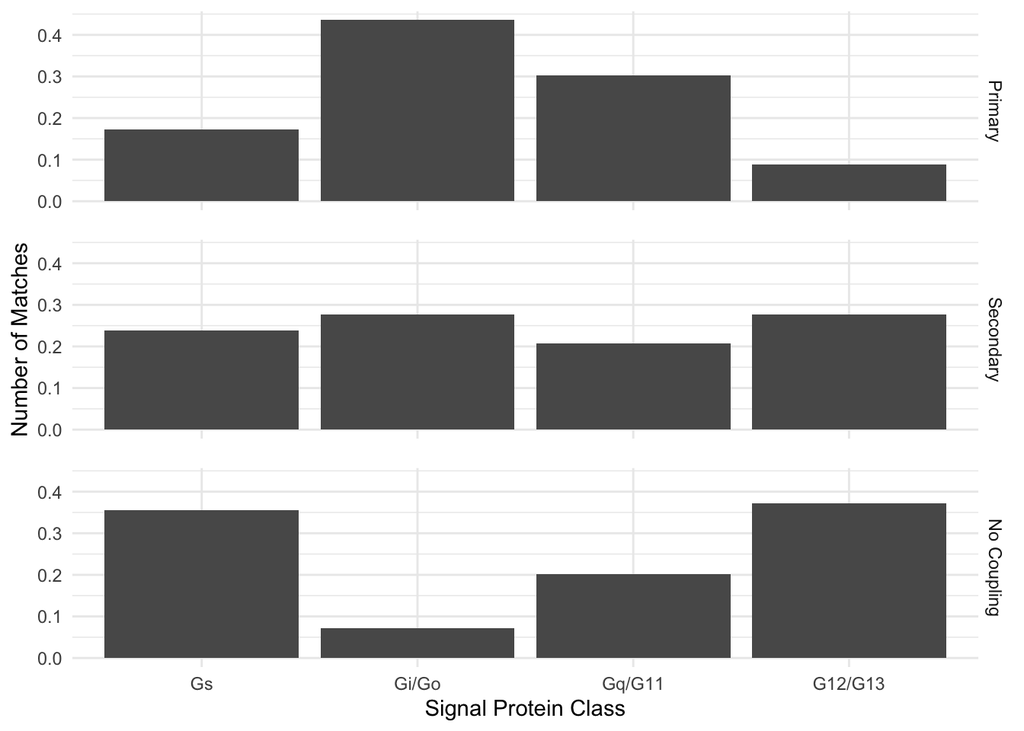

```r
df1 <- df %>%
    group_by(sigprot, coupling) %>%
    summarise(n = n()) %>%
    ungroup() %>%
    group_by(coupling) %>%
    mutate(n2 = n / sum(n)) %>%
    arrange(coupling)

df1$coupling_f = factor(df1$coupling, levels=c('Primary','Secondary', 'No Coupling','No Data'))
df1$sigprot_f = factor(df1$sigprot, levels=c('Gs','Gi/Go', 'Gq/G11','G12/G13'))

plot <- df1 %>%
    ggplot(aes(sigprot_f, n2)) +
      geom_col() +
      theme_minimal() +
      theme(panel.spacing = unit(1, "lines")) +
      facet_grid(coupling_f ~ .) +
      # scale_y_continuous(breaks = seq(0, 20, by = 5)) +
      labs(
        x='Signal Protein Class',
        y='Number of Matches'
      )

ggsave(
  '../images/results/a-gio-search-results.pdf',
  plot,
)
plot
```

This was my first attemp at plotting how many matches i get per combination of coupling level and sigprot. David had a while ago suggested a different way of plotting the data:

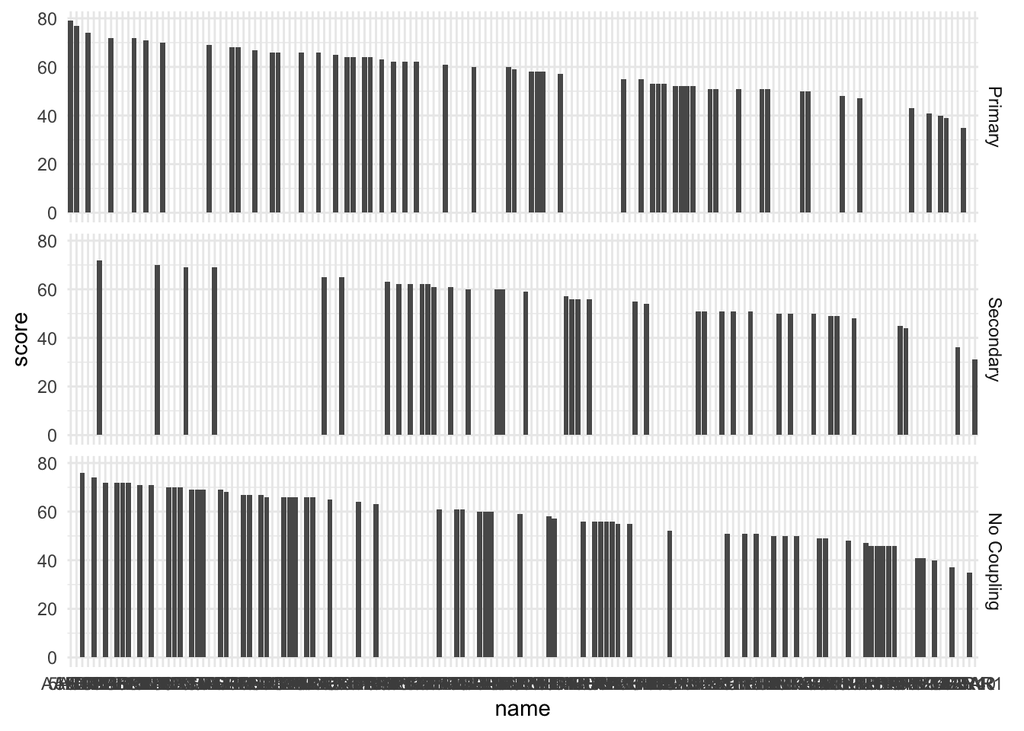

```r
df %>%
  filter(sigprot=='Gs') %>%
  arrange(desc(score)) %>%
  mutate(name=factor(name, levels=name)) %>%
  ggplot(aes(name, score)) +
    geom_bar(stat = 'identity') +
    theme_minimal() +
    facet_grid(coupling_f ~ .)
```

This is receptors on the x-axis, ordered by their score on the y-axis. I dont think this allows for a nice comparison of the underlying distributions of the scores. Also this necessitates a distinct plot for each sigprot. Not ideal in this scenario.

An attempt ot make it easier to compare the distirbutions via a histogram viz:

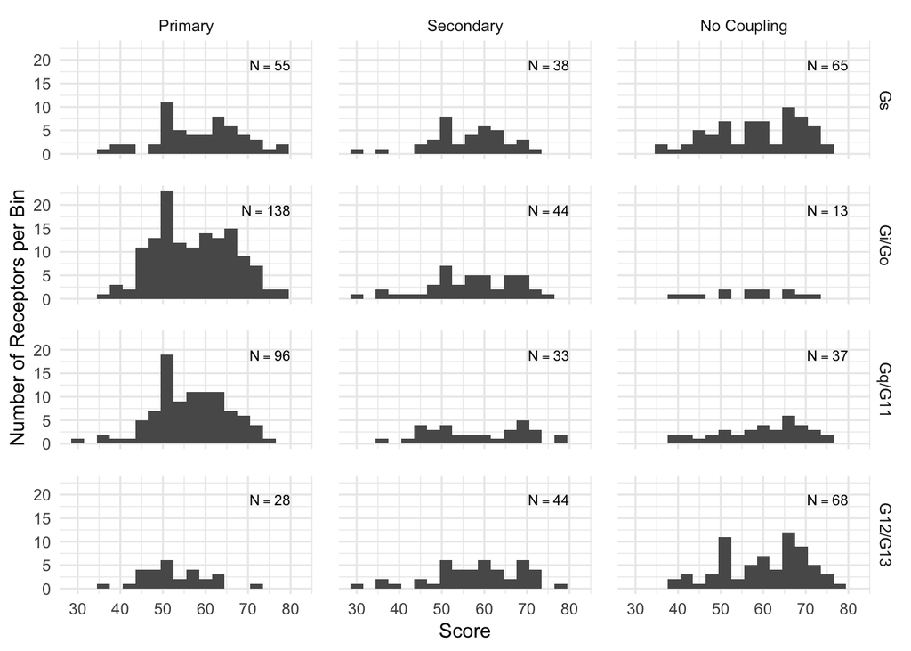

```r
plot_text = df %>%
  group_by(sigprot, coupling) %>%
  summarize(n = n()) %>%
  ungroup() %>%
  mutate(
    x = 80,
    y = 20,
    text = paste0('N==', n))

plot <- df %>%
    left_join(plot_text) %>%
    ggplot(aes(score)) +
      geom_histogram(binwidth = 3) +
      # geom_histogram(aes(y = ..density..), binwidth=density(df$score)$bw) +
      # geom_density(fill="grey20", alpha = 0.2) +
      geom_text(
        aes(
          x=x,
          y=y,
          label = text),
        vjust = "inward",
        hjust = "inward",
        parse = TRUE,
        size = 8 / .pt,
        check_overlap = TRUE) +
      theme_minimal() +
      theme(panel.spacing = unit(1, "lines")) +
      facet_grid(sigprot_f ~ coupling_f) +
      labs(
        x='Score',
        y='Number of Receptors per Bin'
      )
ggsave(
  '../images/results/a-gio-search-results-histo.pdf',
  plot,
)
plot
```

Interesting to see would be if there is a significant difference in the mean score between the distributions of primary coupling and the individual signal proteins.

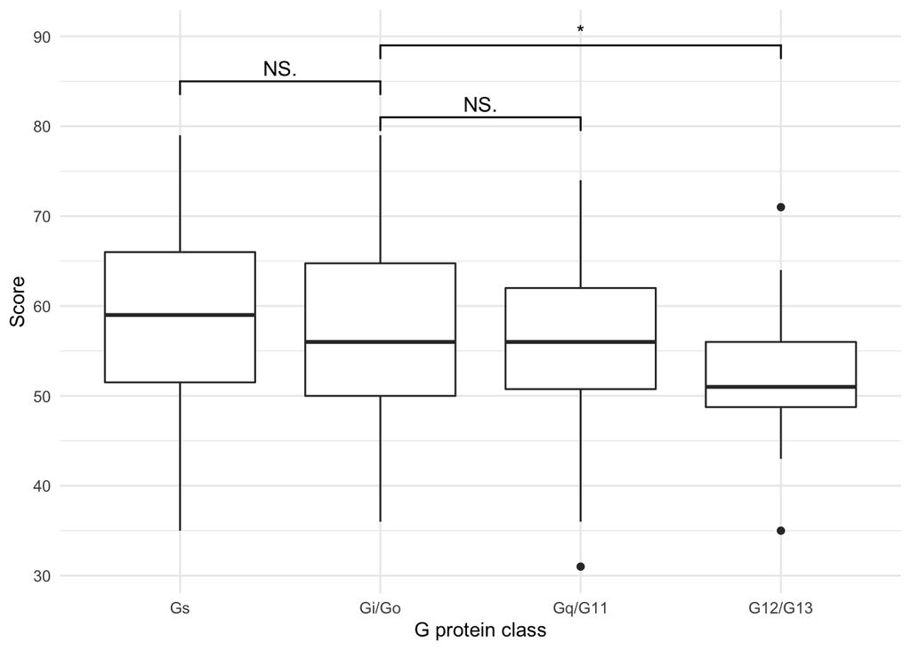

```r
plot <- df %>%
    filter(coupling=='Primary') %>%
    ggplot(aes(sigprot_f, score)) +
      geom_boxplot() +
      geom_signif(
        comparisons = list(
          c("Gi/Go", "Gs"),
          c("Gi/Go", "Gq/G11"),
          c("Gi/Go", "G12/G13")),
        map_signif_level = TRUE,
        test = 'wilcox.test',
        textsize=4,
        y_position=c(85, 81, 89),
        vjust=0.0) +
      theme_minimal() +
      theme(panel.spacing = unit(1, "lines")) +
      # facet_grid(coupling_f ~ .) +
      labs(
        x='G protein class',
        y='Score'
      ) +
      ylim(NA,90)

ggsave(
  '../images/results/a-gio-search-results-sigdiff.pdf',
  plot,
)
plot
```

```r
df %>%
  filter(coupling=='Primary') %>%
  group_by(coupling, sigprot) %>%
  summarise(median(score), sum(score), n())
```

```
## # A tibble: 4 x 5
## # Groups:   coupling [1]
##   coupling sigprot `median(score)` `sum(score)` `n()`
##   <chr>    <chr>             <dbl>        <dbl> <int>
## 1 Primary  G12/G13              51         1469    28
## 2 Primary  Gi/Go                56         7888   138
## 3 Primary  Gq/G11               56         5410    96
## 4 Primary  Gs                   59         3217    55
```

```r
df %>%
  filter(coupling=='Primary') %>%
  group_by(coupling, sigprot) %>%
  mutate(norm_score=score/n()) %>%
  summarise(median(norm_score), sum(norm_score), n())
```

```
## # A tibble: 4 x 5
## # Groups:   coupling [1]
##   coupling sigprot `median(norm_score)` `sum(norm_score)` `n()`
##   <chr>    <chr>                  <dbl>             <dbl> <int>
## 1 Primary  G12/G13                1.82               52.5    28
## 2 Primary  Gi/Go                  0.406              57.2   138
## 3 Primary  Gq/G11                 0.583              56.4    96
## 4 Primary  Gs                     1.07               58.5    55
```

```r
df_norm <- df %>%
  group_by(coupling, sigprot) %>%
  mutate(norm_score=score/n())
df_norm
```

```
## # A tibble: 659 x 7
## # Groups:   coupling, sigprot [12]
##    name  score sigprot coupling    coupling_f  sigprot_f norm_score
##    <chr> <dbl> <chr>   <chr>       <fct>       <fct>          <dbl>
##  1 LT4R1    50 Gs      No Coupling No Coupling Gs             0.769
##  2 GPR17    66 Gs      No Coupling No Coupling Gs             1.02
##  3 CNR2     70 Gs      Secondary   Secondary   Gs             1.84
##  4 HRH2     70 Gs      Primary     Primary     Gs             1.27
##  5 PE2R3    49 Gs      No Coupling No Coupling Gs             0.754
##  6 DRD2     70 Gs      No Coupling No Coupling Gs             1.08
##  7 NPBW1    52 Gs      No Coupling No Coupling Gs             0.8
##  8 RXFP1    47 Gs      Primary     Primary     Gs             0.855
##  9 SSR4     71 Gs      No Coupling No Coupling Gs             1.09
## 10 MRGX2    50 Gs      Secondary   Secondary   Gs             1.32
## # … with 649 more rows
```

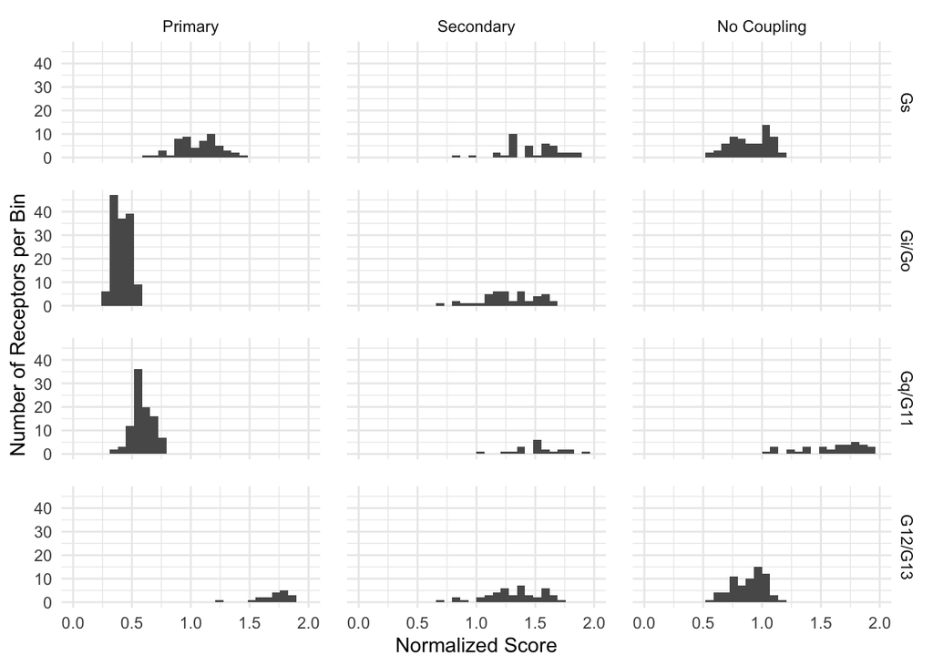

```r
plot <- df_norm %>%
    ggplot(aes(norm_score)) +
      geom_histogram() +
      # geom_histogram(aes(y = ..density..), binwidth=density(df$score)$bw) +
      # geom_density(fill="grey20", alpha = 0.2) +
      theme_minimal() +
      theme(panel.spacing = unit(1, "lines")) +
      facet_grid(sigprot_f ~ coupling_f) +
      labs(
        x='Normalized Score',
        y='Number of Receptors per Bin'
      ) +
      xlim(0,2)
plot
```

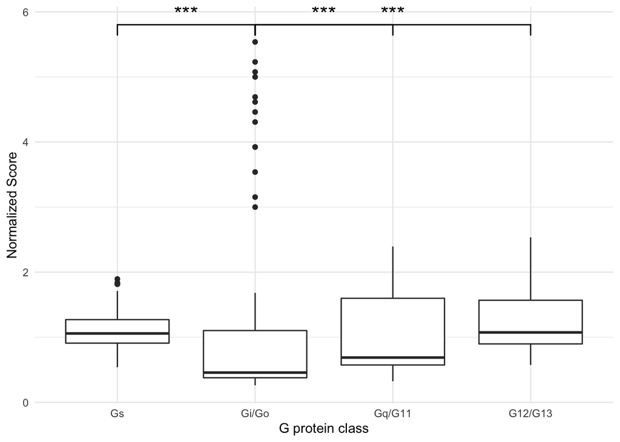

```r
plot <- df_norm %>%
    ggplot(aes(sigprot_f, norm_score)) +
      geom_boxplot() +
      geom_signif(
        comparisons = list(
          c("Gi/Go", "Gq/G11"),
          c("Gi/Go", "G12/G13"),
          c("Gi/Go", "Gs")),
        map_signif_level = TRUE,
        textsize=6) +
      theme_minimal() +
      theme(panel.spacing = unit(1, "lines")) +
      # facet_grid(coupling_f ~ .) +
      labs(
        x='G protein class',
        y='Normalized Score'
      )

plot
```

# Class B - Gs

Read in the exported data from the GPCRdb. The data was generated by selecting the structures of these pdb ids:

- 6B3J
- 6NIY
- 6NBF

The top rows look like this:

```r
df_raw <- read_csv('../data/b1-gs-signature-search.csv')
dim(df_raw)
```

```
## [1] 12 16
```

```r
head(df_raw)
```

```
## # A tibble: 6 x 16
##   name  family subfamily score aska_gs aska_gio aska_gq11 aska_g1213
##   <chr> <chr>  <chr>     <dbl> <chr>   <chr>    <chr>     <chr>
## 1 PACR  Pepti… VIP and …    81 primary no coup… primary   no coupli…
## 2 GHRHR Pepti… Glucagon…    79 <NA>    <NA>     <NA>      <NA>
## 3 VIPR1 Pepti… VIP and …    81 <NA>    <NA>     <NA>      <NA>
## 4 SCTR  Pepti… Glucagon…    81 <NA>    <NA>     <NA>      <NA>
## 5 GLR   Pepti… Glucagon…    79 <NA>    <NA>     <NA>      <NA>
## 6 GLP2R Pepti… Glucagon…    79 <NA>    <NA>     <NA>      <NA>
## # … with 8 more variables: gtop_gs <chr>, gtop_gio <chr>, gtop_gq11 <chr>,
## #   gtop_g1213 <lgl>, merg_gs <chr>, merg_gio <chr>, merg_gq11 <chr>,
## #   merg_g1213 <chr>
```

End goal of this section is to produce a bar chart that highlights the frequency of primary and secondary coupling per g-protein class. I will generate this plot from the top x% or those receptors with a score over a certain threshold. For this I need to:

1. select the columns corresponding to the merged dataset
2. rename the columns
3. sort and filter by signature match score
4. group the entries per g-protein class
5. count the members per group on a primary/secondary coupling level
6. display the groups as bar chart

```r
which_dataset <- 'merg'

df <- df_raw %>%
    select(
        name,
        score,
        starts_with(which_dataset)) %>%
    rename(
        'Gs'=paste0(which_dataset, '_gs'),
        'Gi/Go'=paste0(which_dataset, '_gio'),
        'Gq/G11'=paste0(which_dataset, '_gq11'),
        'G12/G13'=paste0(which_dataset, '_g1213')) %>%
    gather(sigprot, coupling, -name, -score) %>%
    # top_frac(.1, wt=score) %>%
    filter(!is.na(coupling)) %>%
    mutate(coupling=case_when(
      coupling == 'primary' ~ 'Primary',
      coupling == 'secondary' ~ 'Secondary',
      coupling == 'no coupling' ~ 'No Coupling',
      is.na(coupling) ~ 'No Data',
    ))

df$coupling_f = factor(df$coupling, levels=c('Primary','Secondary', 'No Coupling','No Data'))
df$sigprot_f = factor(df$sigprot, levels=c('Gs','Gi/Go', 'Gq/G11','G12/G13'))
```

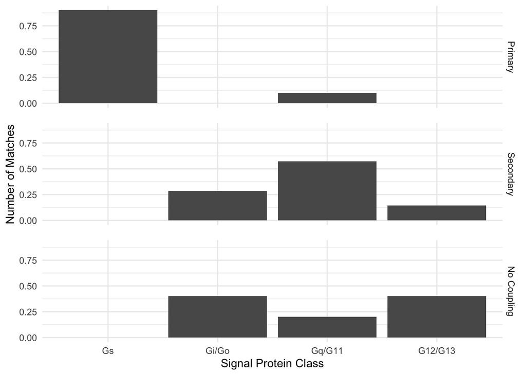

```r
df2 <- df %>%
    group_by(sigprot, coupling) %>%
    summarise(n = n()) %>%
    ungroup() %>%
    group_by(coupling) %>%
    mutate(n2 = n / sum(n)) %>%
    arrange(coupling)

df2$coupling_f = factor(df2$coupling, levels=c('Primary','Secondary', 'No Coupling','No Data'))
df2$sigprot_f = factor(df2$sigprot, levels=c('Gs','Gi/Go', 'Gq/G11','G12/G13'))

plot <- df2 %>%
    ggplot(aes(sigprot_f, n2)) +
      geom_col() +
      theme_minimal() +
      theme(panel.spacing = unit(1, "lines")) +
      facet_grid(coupling_f ~ .) +
      # scale_y_continuous(breaks = seq(0, 20, by = 5)) +
      labs(
        x='Signal Protein Class',
        y='Number of Matches'
      )

ggsave(
  '../images/results/b1-gs-search-results.pdf',
  plot,
)
plot
```

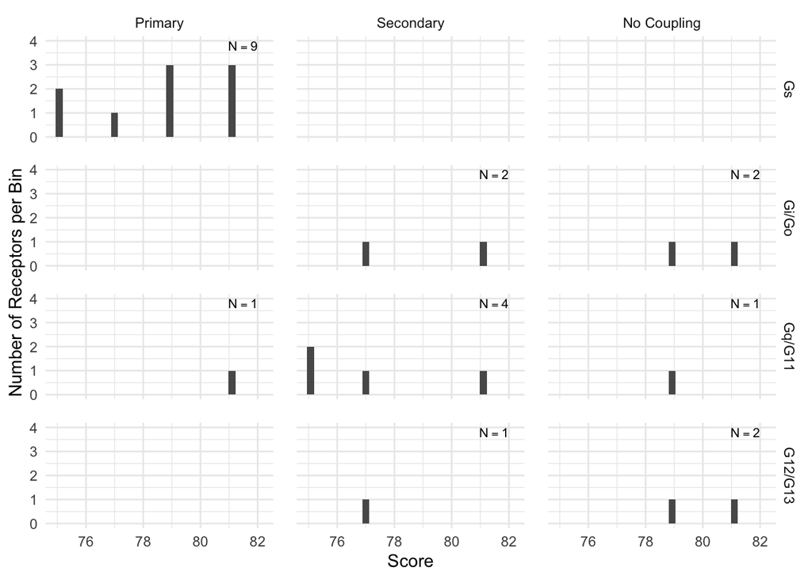

```r
plot_text <- df %>%
  group_by(sigprot, coupling) %>%
  summarize(n = n()) %>%
  ungroup() %>%
  mutate(
    x = 82,
    y = 4,
    text = paste0('N==', n))

plot <- df %>%
    left_join(plot_text) %>%
    ggplot(aes(score)) +
      geom_histogram() +
      # geom_histogram(aes(y = ..density..), binwidth=density(df$score)$bw) +
      # geom_density(fill="grey20", alpha = 0.2) +
      geom_text(
        aes(
          x=x,
          y=y,
          label = text),
        vjust = "inward",
        hjust = "inward",
        parse = TRUE,
        size = 8 / .pt,
        check_overlap = TRUE) +
      theme_minimal() +
      theme(panel.spacing = unit(1, "lines")) +
      facet_grid(sigprot_f ~ coupling_f) +
      labs(
        x='Score',
        y='Number of Receptors per Bin'
      )
ggsave(
  '../images/results/b1-gs-search-results-histo.pdf',
  plot,
)
plot
```

```r
df_raw_a <- read_csv('../data/a-gio-signature-search.csv') %>%
    select(
        name,
        score,
        starts_with(which_dataset)) %>%
    rename(
        'Gs'=paste0(which_dataset, '_gs'),
        'Gi/Go'=paste0(which_dataset, '_gio'),
        'Gq/G11'=paste0(which_dataset, '_gq11'),
        'G12/G13'=paste0(which_dataset, '_g1213')) %>%
    gather(sigprot, coupling, -name, -score) %>%
    # top_frac(.1, wt=score) %>%
    filter(!is.na(coupling)) %>%
    mutate(coupling=case_when(
      coupling == 'primary' ~ 'Primary',
      coupling == 'secondary' ~ 'Secondary',
      coupling == 'no coupling' ~ 'No Coupling',
      is.na(coupling) ~ 'No Data'),
      class='Class A')
df_raw_b <- read_csv('../data/b1-gs-signature-search.csv') %>%
    select(
        name,
        score,
        starts_with(which_dataset)) %>%
    rename(
        'Gs'=paste0(which_dataset, '_gs'),
        'Gi/Go'=paste0(which_dataset, '_gio'),
        'Gq/G11'=paste0(which_dataset, '_gq11'),
        'G12/G13'=paste0(which_dataset, '_g1213')) %>%
    gather(sigprot, coupling, -name, -score) %>%
    filter(!is.na(coupling)) %>%
    mutate(coupling=case_when(
      coupling == 'primary' ~ 'Primary',
      coupling == 'secondary' ~ 'Secondary',
      coupling == 'no coupling' ~ 'No Coupling',
      is.na(coupling) ~ 'No Data'),
      class='Class B1')
```